# Hit and Run Collision Analysis

- [Presentation on hit and run statistics](http://its.ucla.edu/uctc-2013/PDF%20Versions/BCD/Alam.pdf)

*Analyst Notes*.

- A lot of the codes are digits, but they aren't numbers, they are strings. Be sure to use quotes, or your filters will get no matches.

```python
%matplotlib inline
import ambry
import pandas as pd
l = ambry.ilibrary()
b = l.get('chp.ca.gov-switrs-orig-0.1.3')
p = l.get('chp.ca.gov-switrs-orig-collisions').partition
q = """
SELECT *,
strftime('%m',collision_date) AS month, strftime('%Y',collision_date) AS year,  strftime('%w',collision_date) AS dow,
strftime('%W',collision_date) AS week
FROM collisions
WHERE juris BETWEEN 3700 AND 3800
"""

df = p.select(q).pandas
df.head()
```

## Number of Hit and Runs

The data set has 151K collision records from 2001 to 2012. Of that set, 28K were hit and runs, and 4K were fellony hit and runs.

```python
print 'Total Collisions', df['id'].count()
print 'Years from ', min(df['year']), 'to', max(df['year'])
print 'Hit and runs', df[df['hit_and_run'] != 'N']['id'].count()
df.groupby('hit_and_run').case_id.nunique().reset_index()
```

```
Total Collisions 150607
Years from  2001 to 2012
Hit and runs 27724
```

|  | hit_and_run | 0 |
| --- | --- | --- |
| 0 | F | 4026 |
| 1 | M | 23698 |
| 2 | N | 122883 |

3 rows × 2 columns

# Hit and Runs Felonies by Violation Category

Here are the PCF Violation Categories

- 01 - Driving or Bicycling Under the Influence of Alcohol or Drug
- 02 - Impeding Traffic
- 03 - Unsafe Speed
- 04 - Following Too Closely
- 05 - Wrong Side of Road
- 06 - Improper Passing
- 07 - Unsafe Lane Change
- 08 - Improper Turning
- 09 - Automobile Right of Way 6
- 10 - Pedestrian Right of Way
- 11 - Pedestrian Violation
- 12 - Traffic Signals and Signs
- 13 - Hazardous Parking
- 14 - Lights
- 15 - Brakes
- 16 - Other Equipment
- 17 - Other Hazardous Violation
- 18 - Other Than Driver (or Pedestrian)
- 19 -
- 20 -
- 21 - Unsafe Starting or Backing
- 22 - Other Improper Driving
- 23 - Pedestrian or "Other" Under the Influence of Alcohol or Drug
- 24 - Fell Asleep
- 00 - Unknown
- - - Not Stated

- 03 - Unsafe Speed
- 01 - Driving or Bicycling Under the Influence of Alcohol or Drug
- 09 - Automobile Right of Way
- 12 - Traffic Signals and Signs
- 08 - Improper Turning

I'm not sure what the categories mean exactly, but it looks like a lot of them are the fault of the pedestrian.

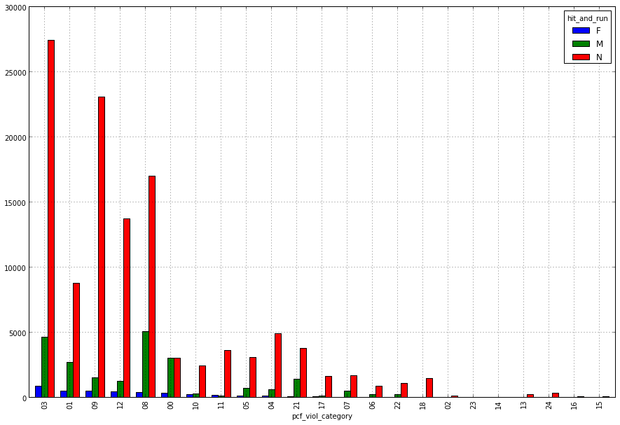

```python
# Group by category and HNR type, then count the number of unique incidents in each group.
# reset_index removes the multi-index, making the output a normal data frame. The, assign
# the colum name for the count column created by nunique
hnr_viol = df.groupby(['pcf_viol_category', 'hit_and_run']).case_id.count().reset_index()
hnr_viol.columns = list(hnr_viol.columns)[:-1]+['count']
# Pivoting turns the values  in the hit_and_run  into columns, with the associated count as the value for the cell
hnr_viol_pivoted = hnr_viol.pivot(index='pcf_viol_category', columns='hit_and_run', values='count')

hnr_viol_pivoted = hnr_viol_pivoted.fillna(0) # Turn NaN into 0
hnr_viol_pivoted.sort(('F','M'), ascending=(0,0), inplace=True)

hnr_viol_pivoted.plot(kind='bar', figsize=(15,10))
```

# Violations Normalized

Same data, but with each category normalized to 1 to show the categories with the highest percentage of felonies.

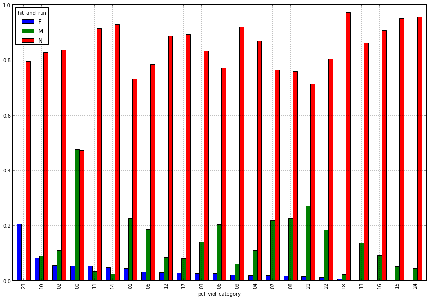

```python
# Normalize by row, so the values for each row sum to 1. ( Making them percentages )
hnr_viol_norm = (hnr_viol_pivoted.T / hnr_viol_pivoted.T.sum()).T # Normalize by row

hnr_viol_norm.sort(('F','M'), ascending=(0,0), inplace=True)

hnr_viol_norm.plot(kind='bar', figsize=(15,10))
```

# Hit and Run Severity

- 1 - Fatal
- 2 - Injury (Severe)
- 3 - Injury (Other Visible)
- 4 - Injury (Complaint of Pain)
- 0 - PDO

The table below is sorted by the number of 1 severities. The categories at the top are:

- 11 - Pedestrian Violation
- 08 - Improper Turning
- 03 - Unsafe Speed
- 01 - Driving or Bicycling Under the Influence of Alcohol or Drug
- 10 - Pedestrian Right of Way

```python
sdf = df[df['hit_and_run'] != 'N']
cat_sev = sdf.groupby(['pcf_viol_category', 'collision_severity']).case_id.count().reset_index()
cat_sev.columns = list(cat_sev.columns)[:-1]+['count']

# Pivoting turns the values  in the hit_and_run  into columns, with the associated count as the value for the cell
cat_sev_pivoted = cat_sev.pivot(index='pcf_viol_category', columns='collision_severity', values='count').fillna(0)
# Normalize by row, so the values for each row sum to 1. ( Making them percentages )

cat_sev_pivoted.sort(('1',), ascending=(0,), inplace=True)
cat_sev_pivoted
```

| collision_severity pcf_viol_category | 0 | 1 | 2 | 3 | 4 |
| --- | --- | --- | --- | --- | --- |
| 11 | 14 | 24 | 85 | 134 | 78 |
| 08 | 4137 | 12 | 62 | 526 | 694 |
| 03 | 3240 | 11 | 49 | 376 | 1830 |
| 01 | 2201 | 10 | 62 | 445 | 499 |
| 10 | 16 | 9 | 35 | 197 | 250 |
| 09 | 978 | 6 | 42 | 320 | 661 |
| 00 | 2872 | 5 | 29 | 132 | 345 |
| 12 | 714 | 3 | 56 | 254 | 695 |
| 23 | 0 | 2 | 2 | 2 | 1 |
| 18 | 28 | 2 | 4 | 8 | 2 |
| 04 | 324 | 2 | 1 | 41 | 359 |
| 17 | 90 | 1 | 12 | 31 | 60 |
| 05 | 592 | 1 | 13 | 109 | 136 |
| 21 | 1268 | 1 | 5 | 61 | 169 |
| 02 | 9 | 1 | 1 | 3 | 7 |
| 15 | 3 | 0 | 0 | 0 | 0 |
| 14 | 1 | 0 | 1 | 0 | 1 |
| 13 | 39 | 0 | 0 | 1 | 1 |
| 16 | 7 | 0 | 0 | 0 | 2 |
| 07 | 449 | 0 | 8 | 30 | 40 |
| 06 | 207 | 0 | 2 | 19 | 40 |
| 22 | 218 | 0 | 2 | 19 | 23 |
| 24 | 13 | 0 | 0 | 2 | 0 |

23 rows × 5 columns